# Bayesian Optimisation for Group Sequential Clinical Trial Design

2026-04-16

## Group Sequential Clinical Trials - Refresher

## Planning an RCT

A randomised clinical trial compares a treatment, \(T\), to a control, \(C\)

## Planning an RCT

A randomised clinical trial compares a treatment, \(T\), to a control, \(C\)

Frequentist operating characteristics are controlled:

- type I error rate, \(\alpha\)
- type II error rate, \(\beta\) (or power, \(1-\beta\))

## Planning an RCT

A randomised clinical trial compares a treatment, \(T\), to a control, \(C\)

Frequentist operating characteristics are controlled:

- type I error rate, \(\alpha\)
- type II error rate, \(\beta\) (or power, \(1-\beta\))

If \(\theta\) is a random variable denoting some measure of difference \(T-C\):

| One-sided hypothesis | Statement |
| --- | --- |
| Null hypothesis | \(H_0: \theta \le 0\) |
| Alt hypothesis | \(H_a: \theta > 0\) |

## Planning an RCT

Fixed sample test for some clinically meaningful difference \(\delta\):

1. Choose \(c\) such that \(P(Z>c\,|\,\theta=0)=\alpha\)
2. Choose sample size \(n\) such that \(P(Z > c\,|\,\theta=\delta) \ge 1-\beta\)

Reject \(H_0\) if \(Z>c\).

## Group sequential design

Multiple analyses are performed throughout the trial.

## Group sequential design

Multiple analyses are performed throughout the trial.

If we have \(K\) total analyses, one possible design, \(D\), defines boundaries:

- \(\boldsymbol{\ell} = \{\ell_1, \ell_2, \dots,\ell_K\}\)
- \(\mathbf{u} = \{u_1, u_2, \dots,u_K\}\)

## Group sequential design

Multiple analyses are performed throughout the trial.

If we have \(K\) total analyses, one possible design, \(D\), defines boundaries:

- \(\boldsymbol{\ell} = \{\ell_1, \ell_2, \dots,\ell_K\}\)
- \(\mathbf{u} = \{u_1, u_2, \dots,u_K\}\)

And a sample size, \(n\), constant at each stage:

- \(\mathbf{n}=\{n_1, \dots, n_K\}\) where \(n_1=\dots=n_K\) and
- each group \(T_k\) and \(C_k\) has size \(\frac{n}{2}\)

## Group sequential design

Multiple analyses are performed throughout the trial.

If we have \(K\) total analyses, one possible design, \(D\), defines boundaries:

- \(\boldsymbol{\ell} = \{\ell_1, \ell_2, \dots,\ell_K\}\)
- \(\mathbf{u} = \{u_1, u_2, \dots,u_K\}\)

And a sample size, \(n\), constant at each stage:

- \(\mathbf{n}=\{n_1, \dots, n_K\}\) where \(n_1=\dots=n_K\) and
- each group \(T_k\) and \(C_k\) has size \(\frac{n}{2}\)

If we naively test, for instance, all upper bounds set such that \(P(Z>c\,|\,\theta=0)=\alpha\) as defined previously, **type I error will be inflated**.

## Group sequential design

Multiple analyses are performed throughout the trial.

If we have \(K\) total analyses, one possible design, \(D\), defines boundaries:

- \(\boldsymbol{\ell} = \{\ell_1, \ell_2, \dots,\ell_K\}\)
- \(\mathbf{u} = \{u_1, u_2, \dots,u_K\}\)

And a sample size, \(n\), constant at each stage:

- \(\mathbf{n}=\{n_1, \dots, n_K\}\) where \(n_1=\dots=n_K\) and
- each group \(T_k\) and \(C_k\) has size \(\frac{n}{2}\)

If we naively test, for instance, all upper bounds set such that \(P(Z>c\,|\,\theta=0)=\alpha\) as defined previously, **type I error will be inflated**.

**Boundary critical values must be adjusted to control for this.**

## Group sequential design

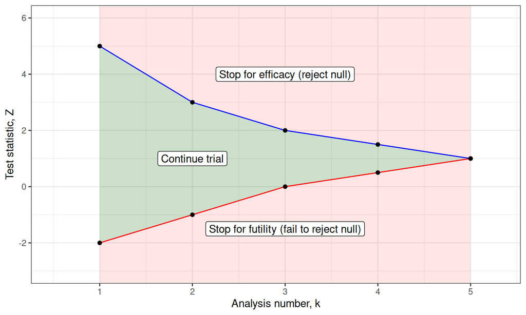

## Group sequential design

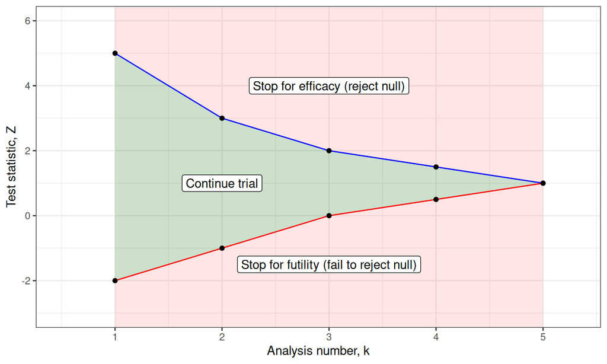

**Problem: an *infinite* number of possible designs!**

## Gaussian processes: Motivating problem

## Non-linear regression

Given \(n\) data points \(\{x_i, y_i\}_{i=1}^n \xrightarrow{\text{Predict}} (x_{\texttt{new}}, y_{\texttt{new}})\)

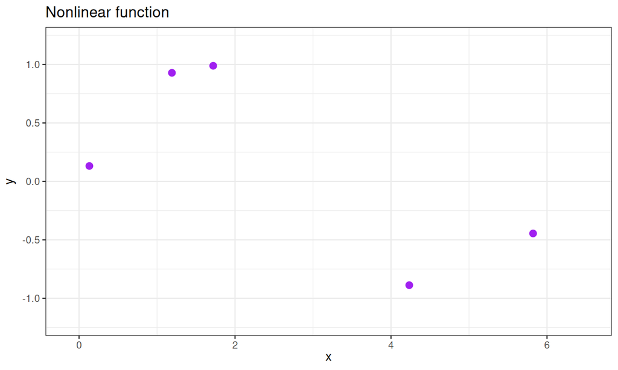

## Non-linear regression

Given \(n\) data points \(\{x_i, y_i\}_{i=1}^n \xrightarrow{\text{Predict}} (x_{\texttt{new}}, y_{\texttt{new}})\)

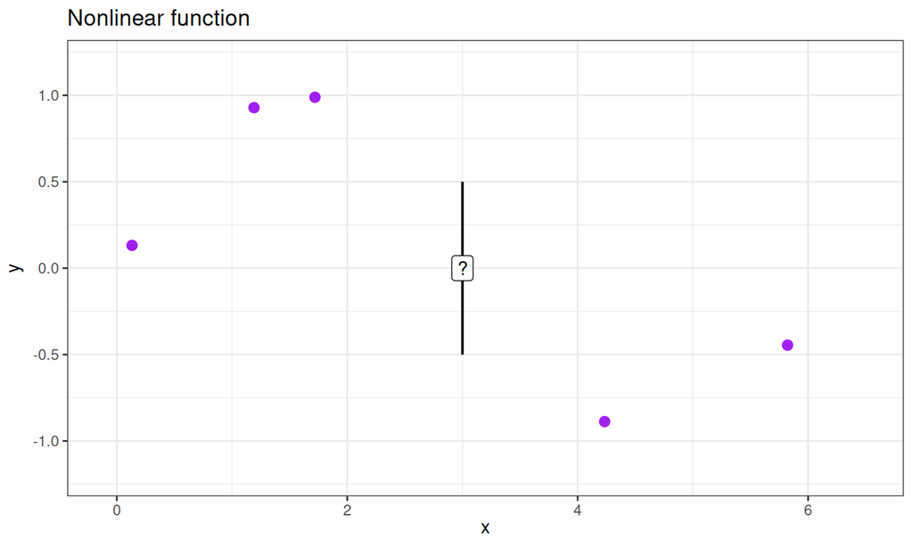

## Non-linear regression

Given \(n\) data points \(\{x_i, y_i\}_{i=1}^n \xrightarrow{\text{Predict}} (x_{\texttt{new}}, y_{\texttt{new}})\)

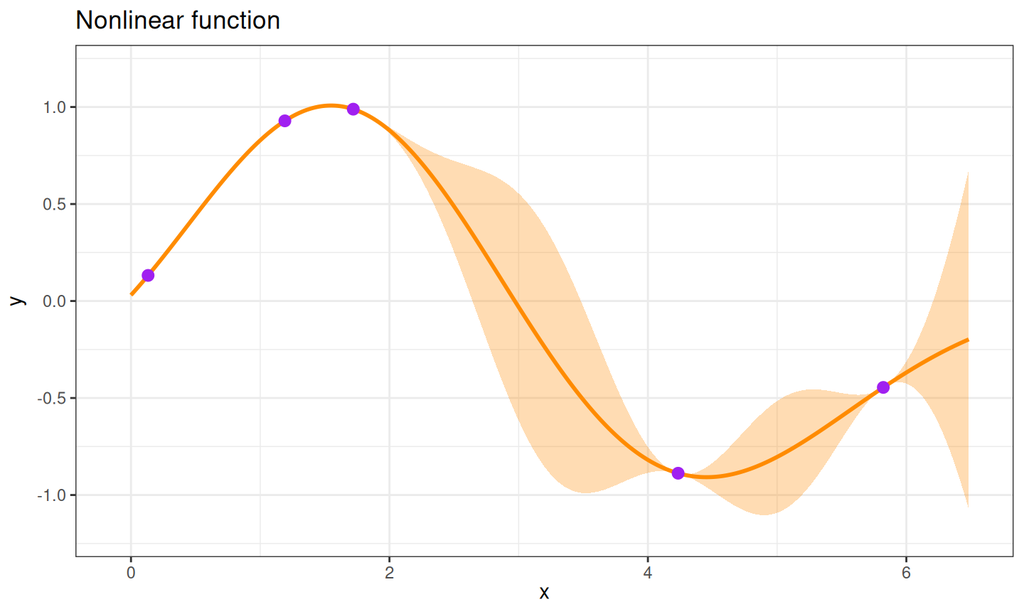

## Non-linear regression

Given \(n\) data points \(\{x_i, y_i\}_{i=1}^n \xrightarrow{\text{Predict}} (x_{\texttt{new}}, y_{\texttt{new}})\)

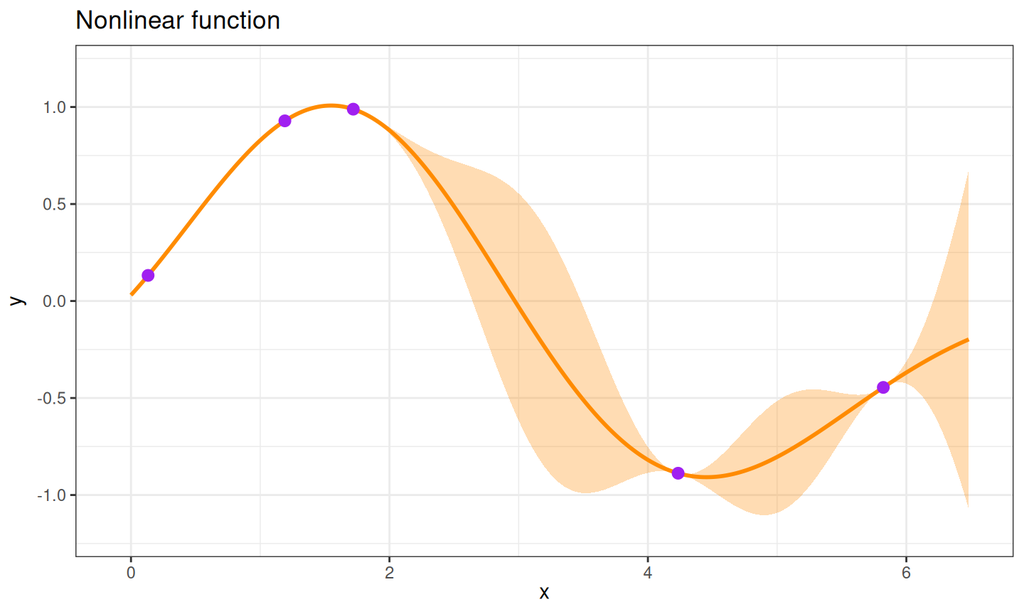

**Can all be done with Gaussian distributions!**

## Review of the Multivariate Normal (MVN) in 2-d

If we have a vector of random variables \(\mathbf{x}\) and

\[ \mathbf{x} \sim \mathcal{N}_d(\boldsymbol{\mu}, \mathbf{\Sigma}) \]

then, the joint probability mass of \(\mathbf{x}\) is given by the multivariate normal:

\[ p\left( \mathbf{x} \,|\, \boldsymbol{\mu}, \mathbf{\Sigma} \right) \propto \exp \left\{ -\frac{1}{2} (\mathbf{x}-\boldsymbol{\mu})^\top \Sigma^{-1} (\mathbf{x}-\boldsymbol{\mu}) \right\} \]

## Review of the Multivariate Normal (MVN) in 2-d

A two-dimensional MVN with \(\boldsymbol{\mu}=[0,0]\) and \(\Sigma=\begin{bmatrix} 1 & 0.7\\ 0.7 & 1 \end{bmatrix}\):

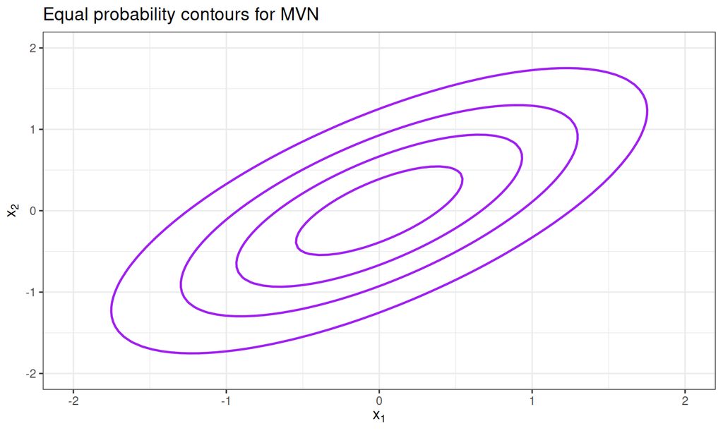

## Review of the Multivariate Normal (MVN) in 2-d

MVN pdf in 3 dimensions:

[interactive chart not shown]

## Review of the Multivariate Normal (MVN) in 2-d

Probability contour plot:

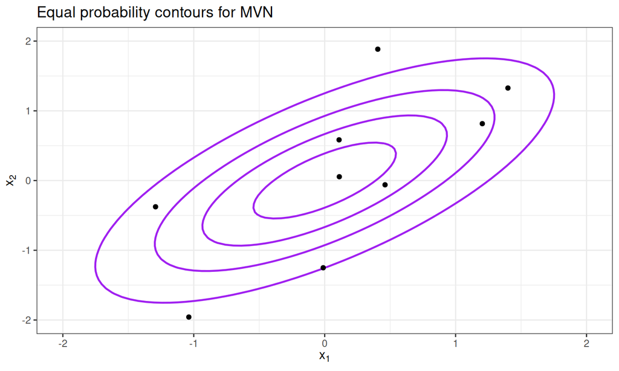

## Conditioning of the MVN in 2-d

We can condition on one of the variables, \(p(x_2 \,|\, x_1,\,\Sigma)\)

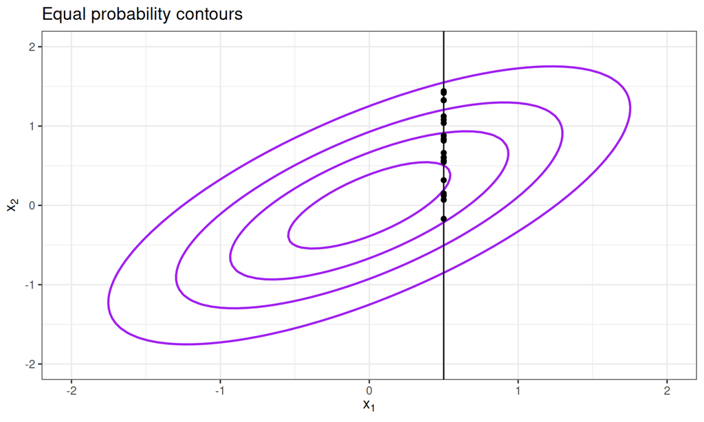

## Intro to Gaussian Processes

## MVN in mulitple dimentions

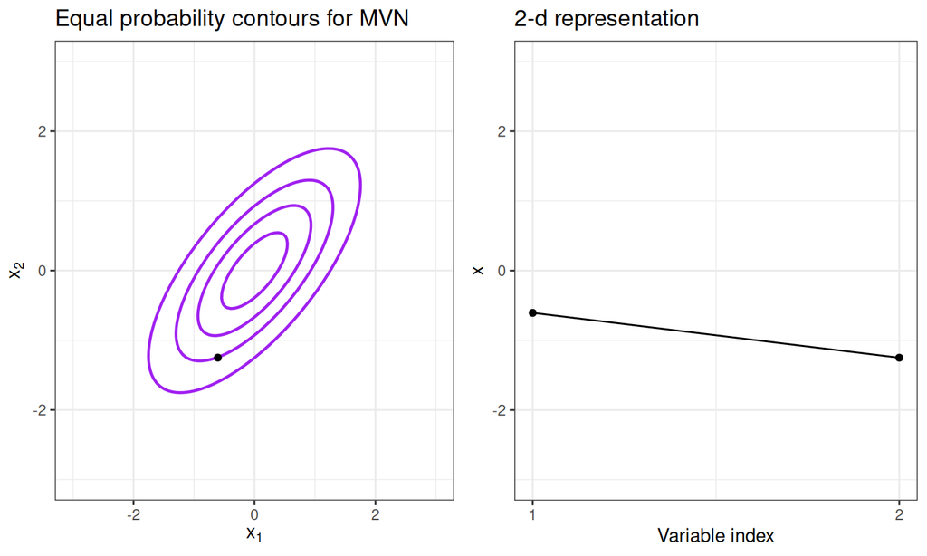

\[ \mathbf{\Sigma} = \begin{bmatrix} 1 & 0.7\\ 0.7 & 1 \end{bmatrix} \]

## MVN in mulitple dimentions

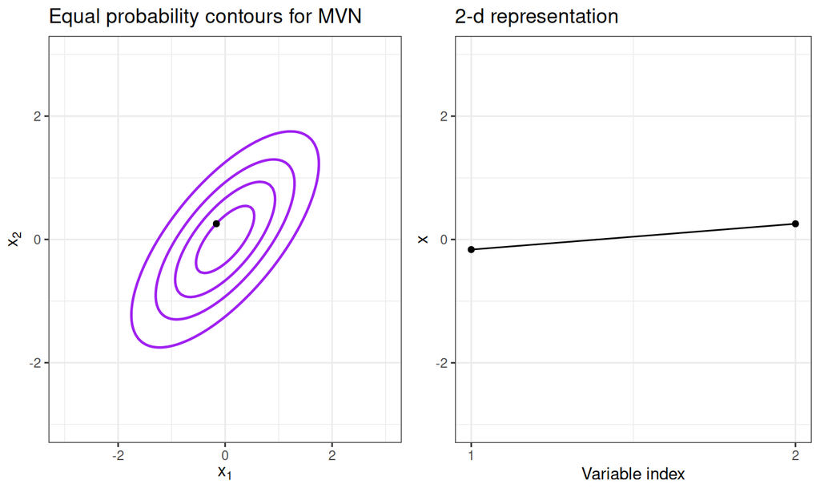

\[ \mathbf{\Sigma} = \begin{bmatrix} 1 & 0.7\\ 0.7 & 1 \end{bmatrix} \]

## MVN in mulitple dimentions

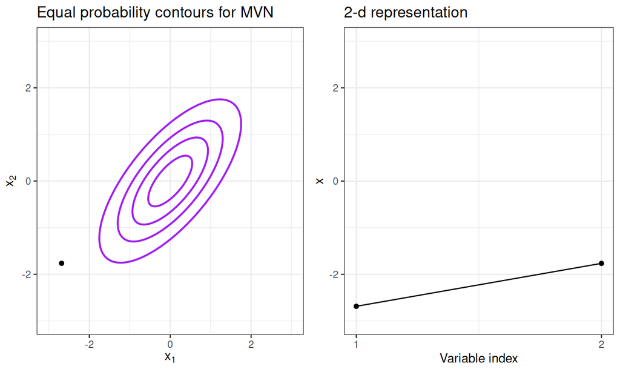

\[ \mathbf{\Sigma} = \begin{bmatrix} 1 & 0.7\\ 0.7 & 1 \end{bmatrix} \]

## MVN in mulitple dimentions

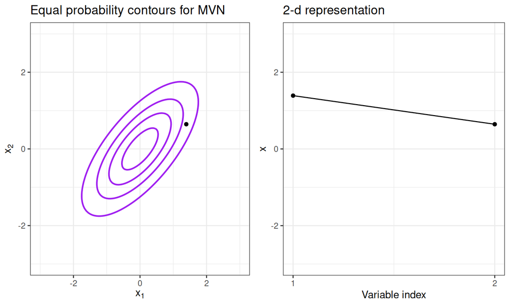

\[ \mathbf{\Sigma} = \begin{bmatrix} 1 & 0.7\\ 0.7 & 1 \end{bmatrix} \]

## MVN in mulitple dimentions

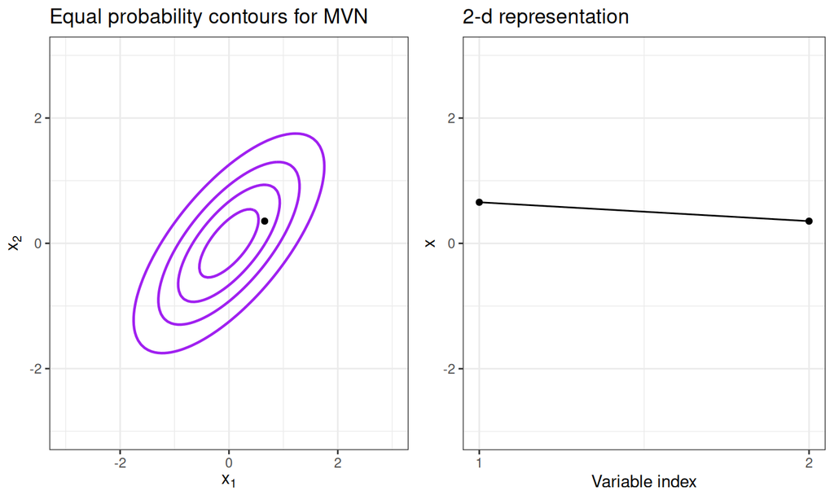

\[ \mathbf{\Sigma} = \begin{bmatrix} 1 & 0.7\\ 0.7 & 1 \end{bmatrix} \]

## MVN in mulitple dimentions

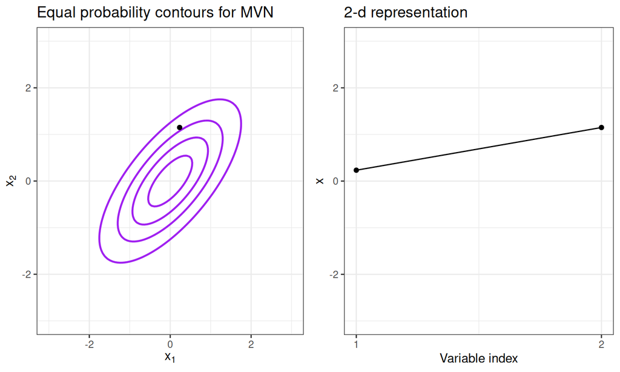

\[ \mathbf{\Sigma} = \begin{bmatrix} 1 & 0.7\\ 0.7 & 1 \end{bmatrix} \]

## MVN in mulitple dimentions

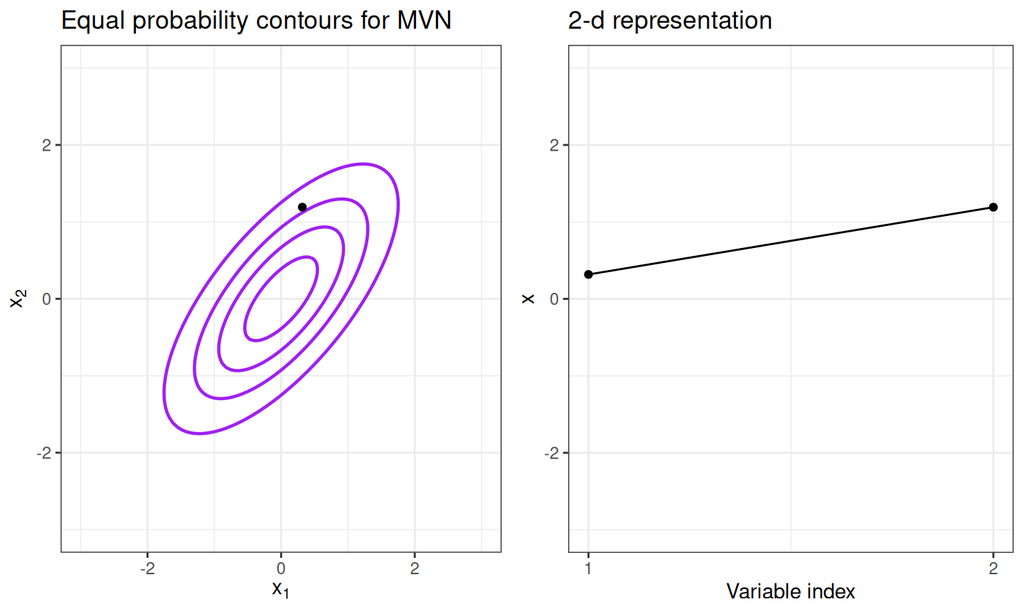

\[ \mathbf{\Sigma} = \begin{bmatrix} 1 & 0.7\\ 0.7 & 1 \end{bmatrix} \]

## \(\Sigma\) matrix in 10 dimensions

\[ \mathbf{\Sigma} = \begin{bmatrix} 1.00 & 0.90 & 0.67 & 0.41 & 0.20 & 0.08 & 0.03 & 0.01 & 0.00 & 0.00 \\ 0.90 & 1.00 & 0.90 & 0.67 & 0.41 & 0.20 & 0.08 & 0.03 & 0.01 & 0.00 \\ 0.67 & 0.90 & 1.00 & 0.90 & 0.67 & 0.41 & 0.20 & 0.08 & 0.03 & 0.01 \\ 0.41 & 0.67 & 0.90 & 1.00 & 0.90 & 0.67 & 0.41 & 0.20 & 0.08 & 0.03 \\ 0.20 & 0.41 & 0.67 & 0.90 & 1.00 & 0.90 & 0.67 & 0.41 & 0.20 & 0.08 \\ 0.08 & 0.20 & 0.41 & 0.67 & 0.90 & 1.00 & 0.90 & 0.67 & 0.41 & 0.20 \\ 0.03 & 0.08 & 0.20 & 0.41 & 0.67 & 0.90 & 1.00 & 0.90 & 0.67 & 0.41 \\ 0.01 & 0.03 & 0.08 & 0.20 & 0.41 & 0.67 & 0.90 & 1.00 & 0.90 & 0.67 \\ 0.00 & 0.01 & 0.03 & 0.08 & 0.20 & 0.41 & 0.67 & 0.90 & 1.00 & 0.90 \\ 0.00 & 0.00 & 0.01 & 0.03 & 0.08 & 0.20 & 0.41 & 0.67 & 0.90 & 1.00 \end{bmatrix} \]

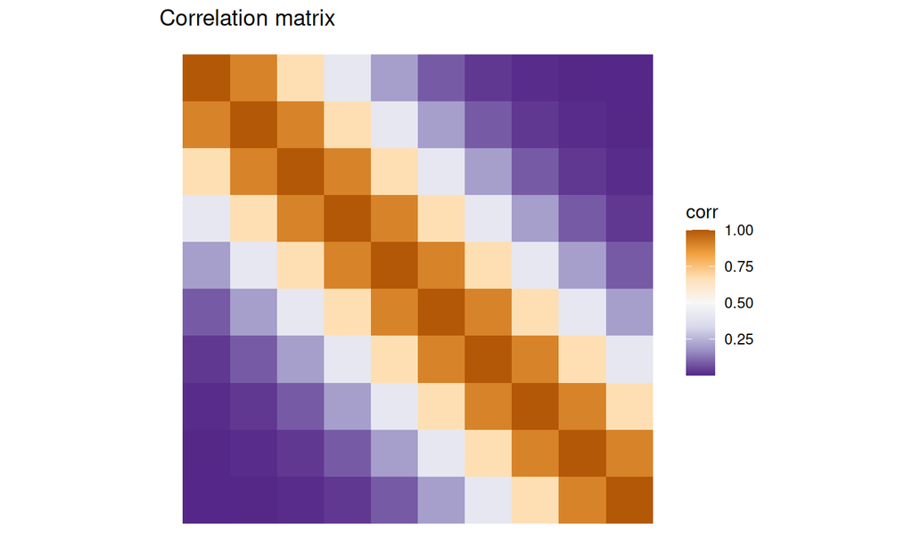

## MVN in mulitple dimentions

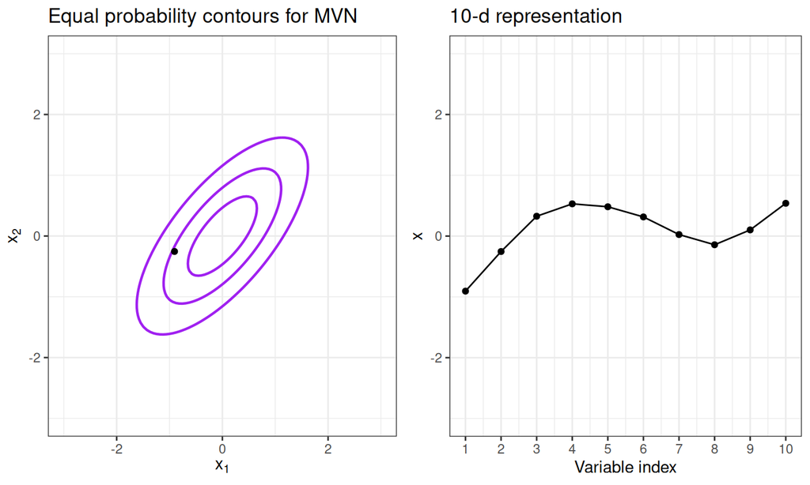

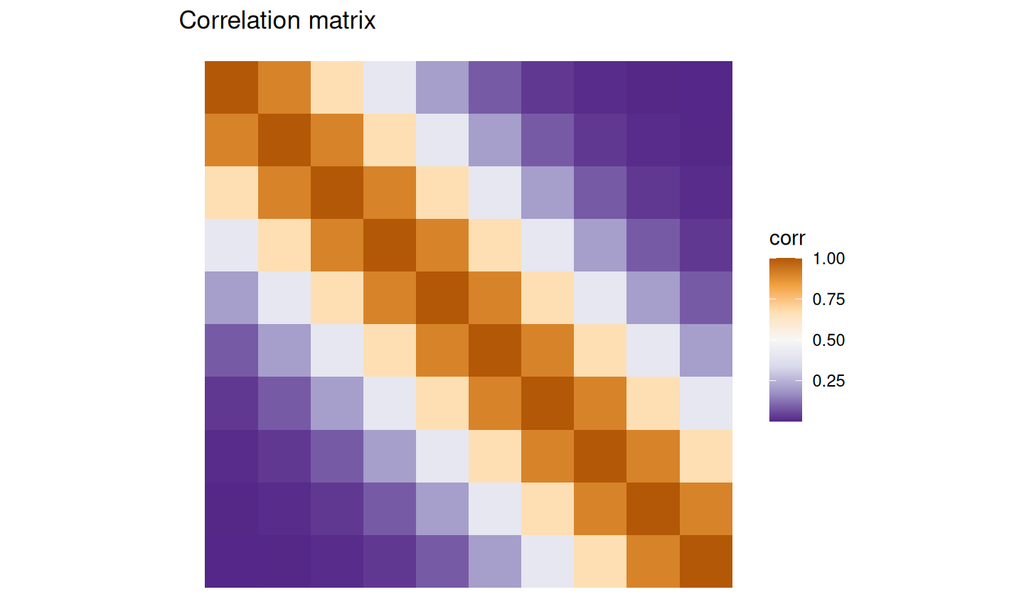

## MVN in mulitple dimentions

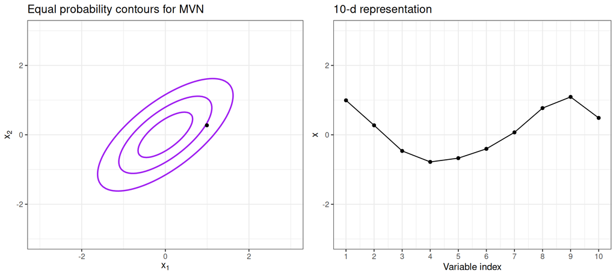

## MVN in mulitple dimentions

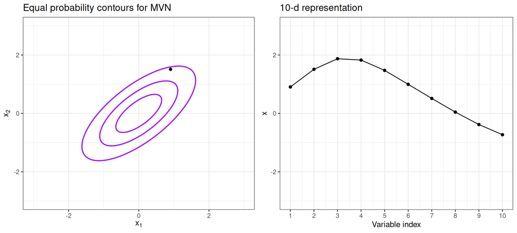

## MVN in mulitple dimentions

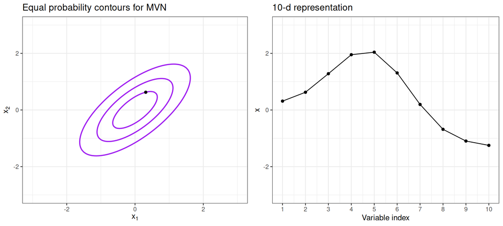

## MVN in mulitple dimentions

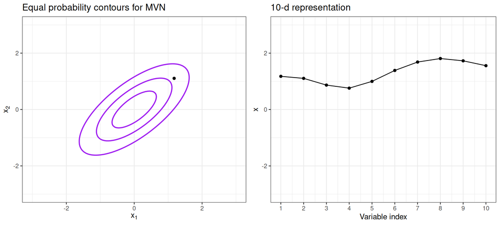

## MVN in mulitple dimentions

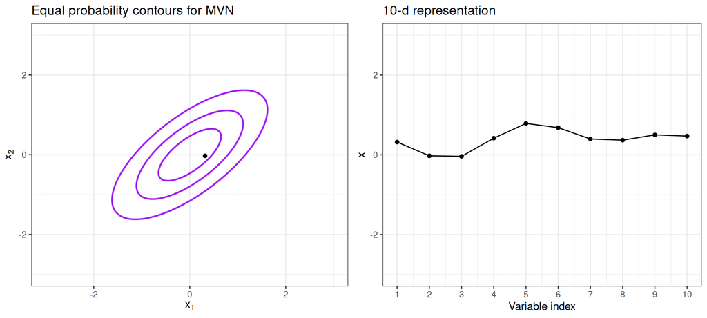

## MVN in mulitple dimentions

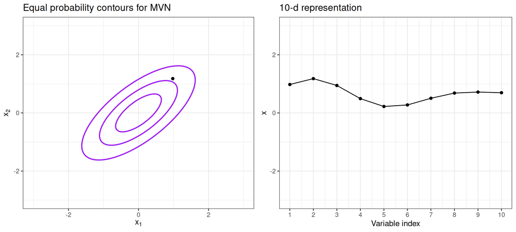

## MVN in mulitple dimentions

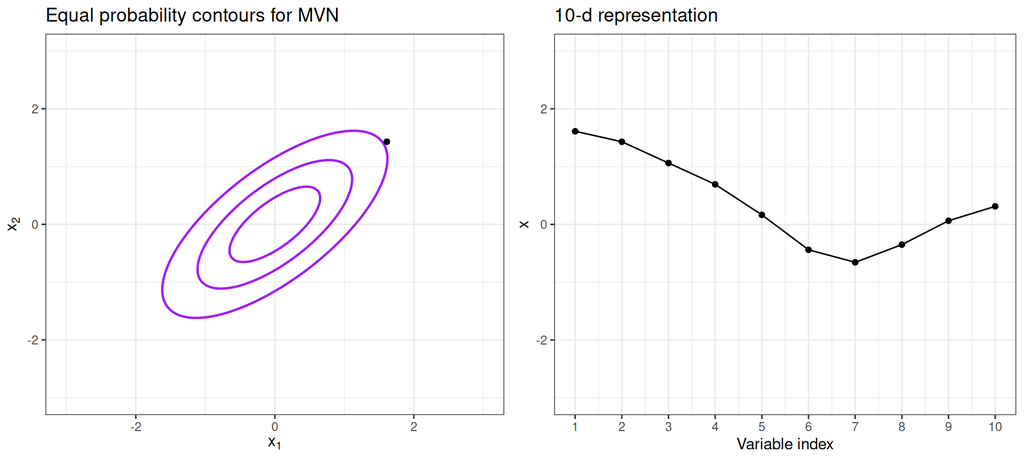

## MVN in mulitple dimentions

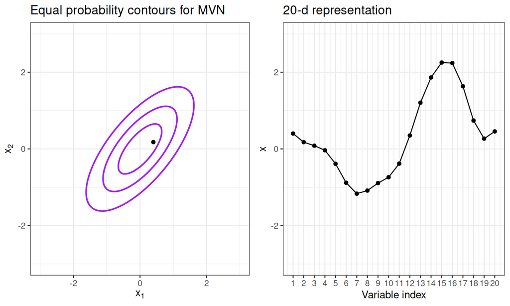

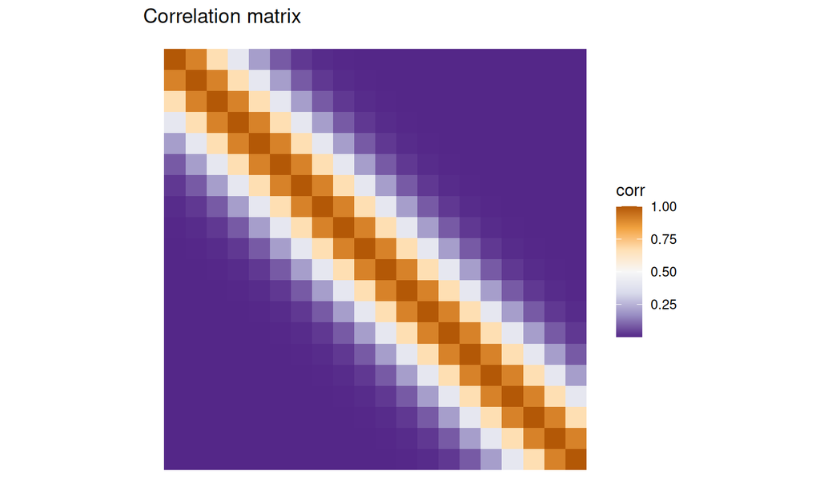

## MVN in mulitple dimentions

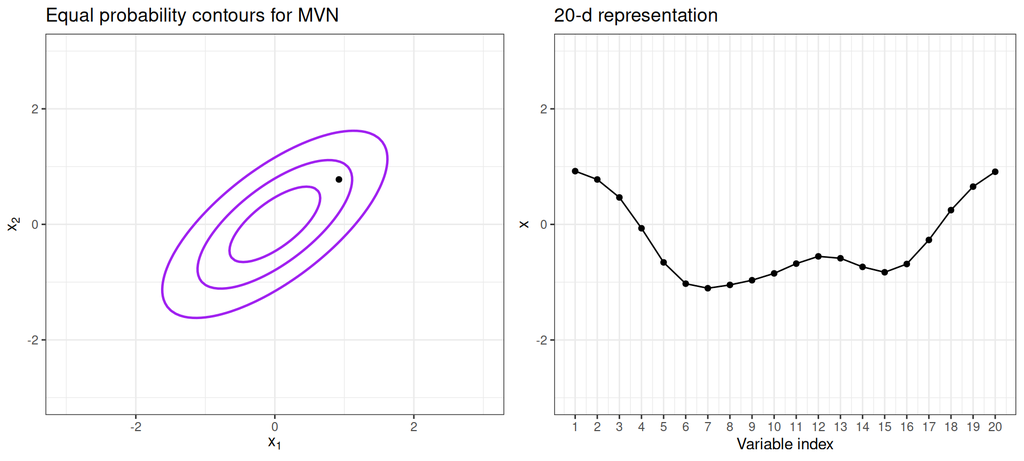

## MVN in mulitple dimentions

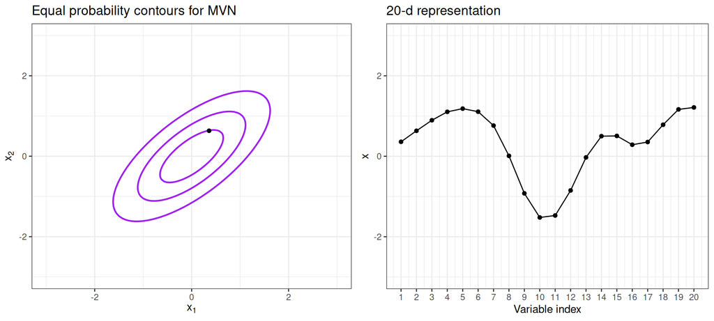

## MVN in mulitple dimentions

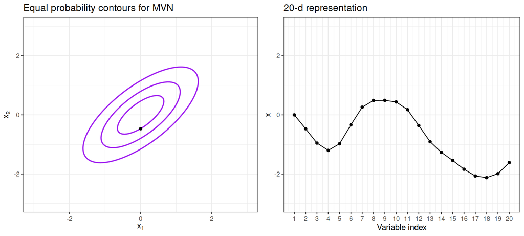

## MVN in mulitple dimentions

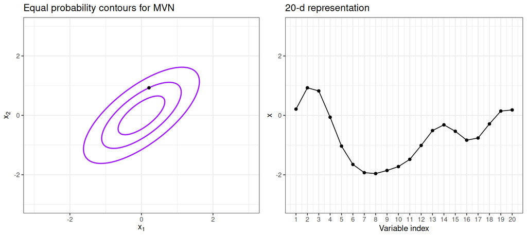

## MVN in mulitple dimentions

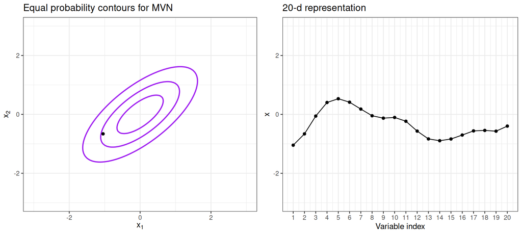

## MVN in mulitple dimentions

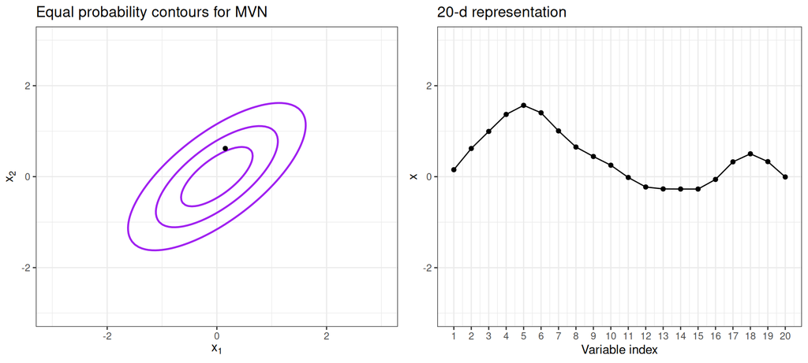

## MVN in mulitple dimentions

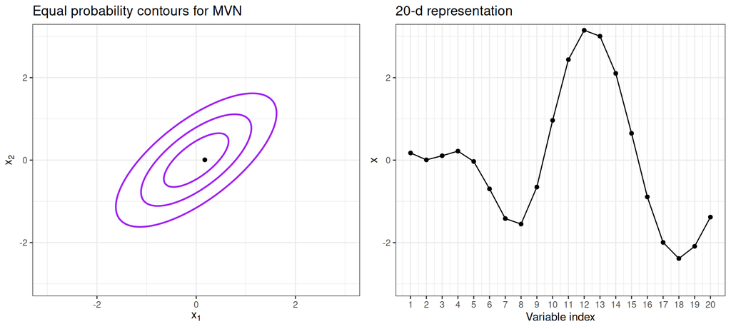

## Fixing points with the conditional distribution

In a simple example, imagine we are given three data points \(\{(x_i, y_i)\}_{i=1}^3\). We need to predict the function thereafter

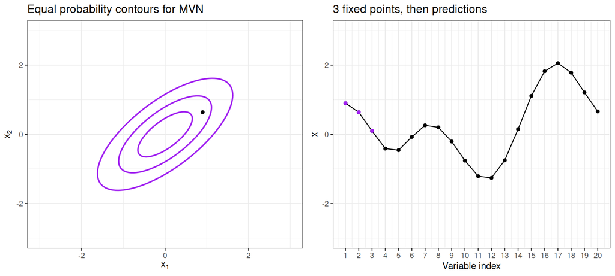

## Fixing points with the conditional distribution

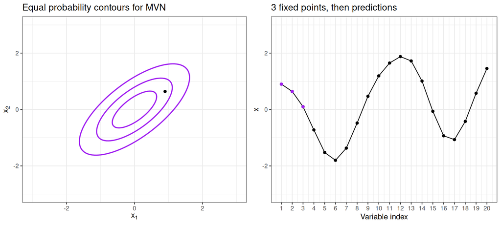

## Fixing points with the conditional distribution

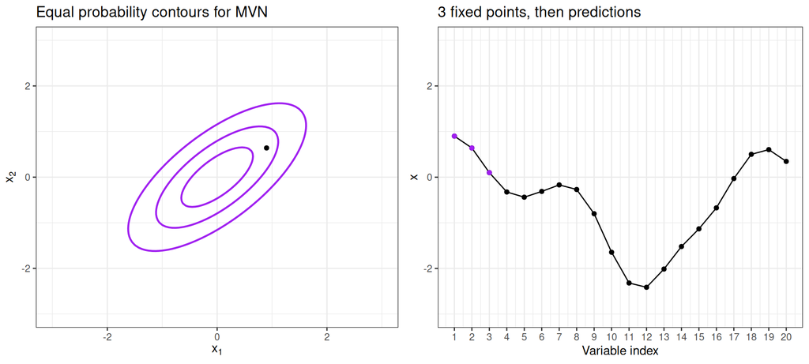

## Fixing points with the conditional distribution

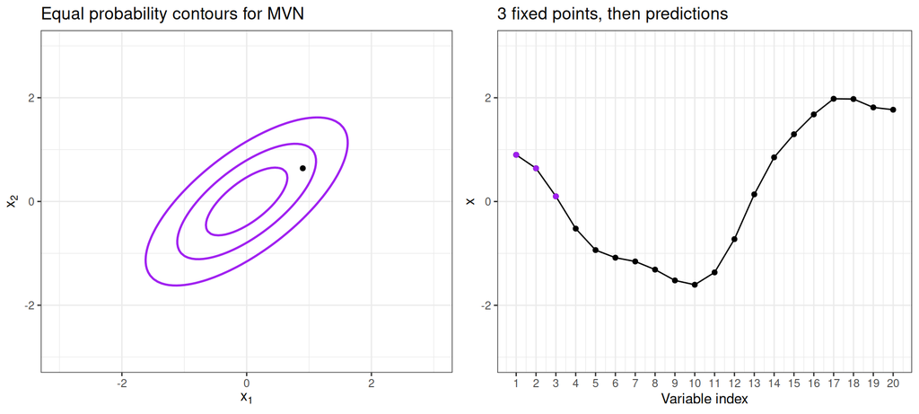

## Fixing points with the conditional distribution

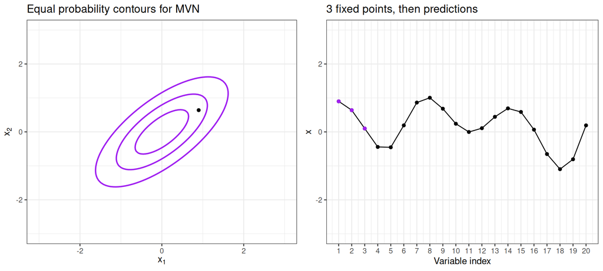

## Fixing points with the conditional distribution

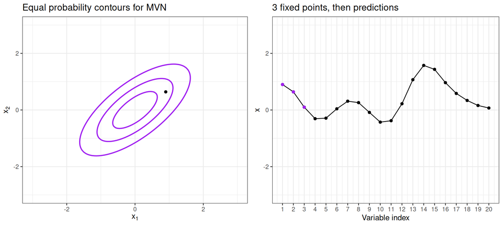

## Fixing points with the conditional distribution

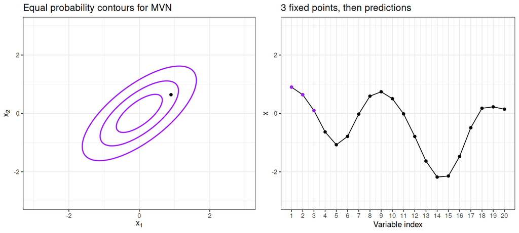

## Fixing points with the conditional distribution

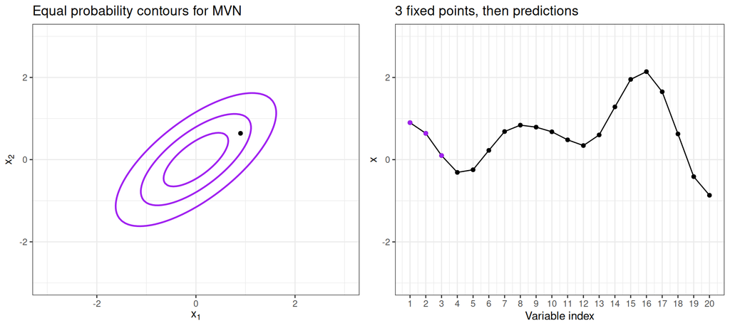

## Mathematical formalism

## Definition of Gaussian Processes (GPs)

A Gaussian process is a generalization of a multivariate Gaussian distribution to **infinitely** many variables.

*A Gaussian process is a collection of random variables, any finite number of which have a joint Gaussian distribution.*

As a distribution over functions, a Gaussian process is completely specified by two functions:

- A mean function, \(m(\mathbf{x}) = \mathbb{E}[f(\mathbf{x})]\) and
- A covariance function, \(k(\mathbf{x}, \mathbf{x^\star}) = \mathbb{E}\Big[\big(f(\mathbf{x})- m(\mathbf{x})\big)\big(f(\mathbf{x^\star}) - m(\mathbf{x^\star})\big)^\mathsf{T} \Big]\)

\[ f(\mathbf{x}) \sim \mathcal{GP}\big(\, m(\mathbf{x}), k(\mathbf{x}, \mathbf{x^\star}) \, \big) \]

## Regression

Generative model

\[ y(\mathbf{x}) = f(\mathbf{x}) \Big[ + \epsilon\sigma_y \Big]\\ p(\epsilon)=\mathcal{N}(0,1) \]

Place GP prior over the nonlinear function (mean function often taken as 0).

\[ p(f(\mathbf{x}) \, | \, \theta) = \mathcal{GP}\big(0, k(\mathbf{x}, \mathbf{x^\star})\big)\\ k(\mathbf{x}, \mathbf{x^\star}) = \sigma^2 \exp \left\{ -\frac{1}{2\ell^2}(x-x^\star)^2 \right\} \]

## Predictions

\[ p(\mathbf{y}_1, \mathbf{y}_2) = \mathcal{N} \left( \begin{bmatrix} \boldsymbol{\mu}_1\\ \boldsymbol{\mu}_2 \end{bmatrix}, \begin{bmatrix} \mathbf{\Sigma}_{11} & \mathbf{\Sigma}_{12}\\ \mathbf{\Sigma}_{21} & \mathbf{\Sigma}_{22} \end{bmatrix}\right) \] Bayes’ theorem:

\[ p(\mathbf{y}_1 \,|\, \mathbf{y}_2) = \frac{p(\mathbf{y}_1, \mathbf{y}_2)}{p(\mathbf{y}_2)} \]

With an involved proof:

- Predictive mean (linear projection in inverse distance space): \(\boldsymbol{\mu}_{\mathbf{y}_1|\mathbf{y}_2} = \boldsymbol{\mu}_1 + \mathbf{\Sigma}_{12}\mathbf{\Sigma}_{22}^{-1}(\mathbf{y}_2-\boldsymbol{\mu}_2)\)
- Predictive variance (quadratic reduction in variance): \(\mathbf{\Sigma}_{\mathbf{y}_1|\mathbf{y}_2} = \mathbf{\Sigma}_{11} - \mathbf{\Sigma}_{12}\mathbf{\Sigma}_{22}^{-1}\mathbf{\Sigma}_{21}\)

## Final visualization

## Initial conditions

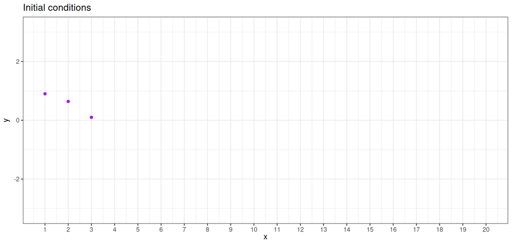

## Mean prediction

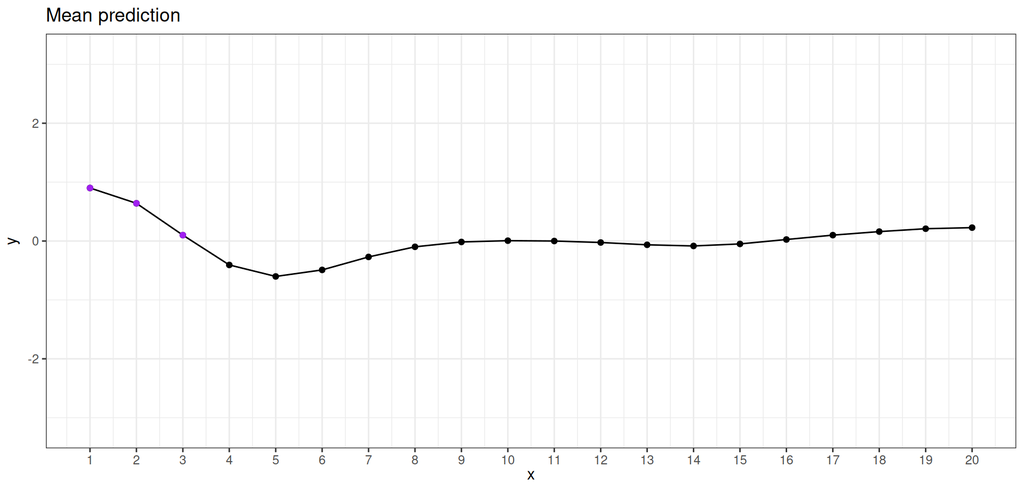

## Mean prediction + 100 function draws

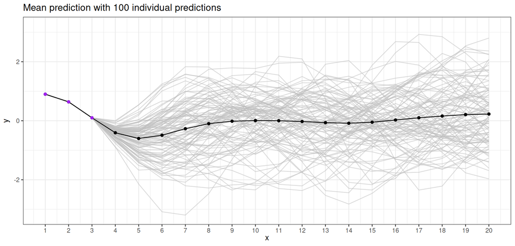

## Mean prediction + 100 function draws + new point

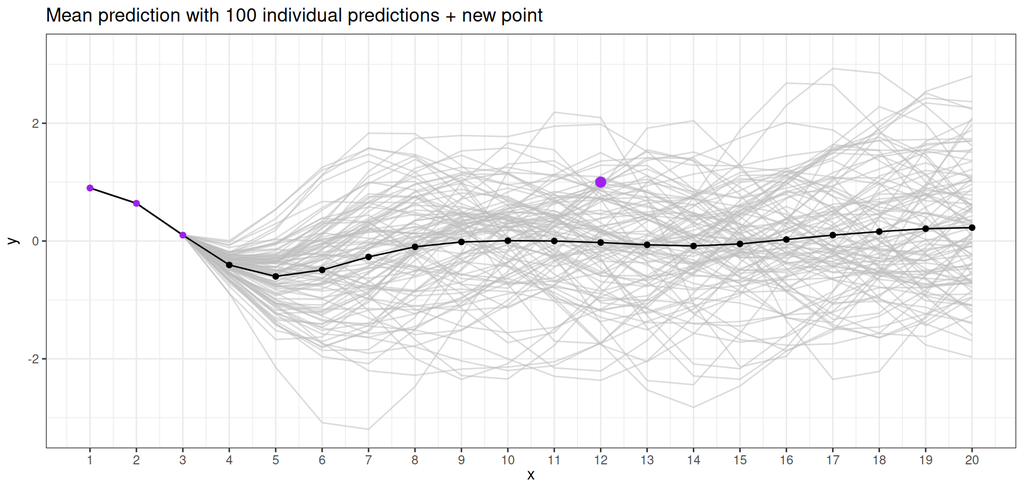

## Add a point further away

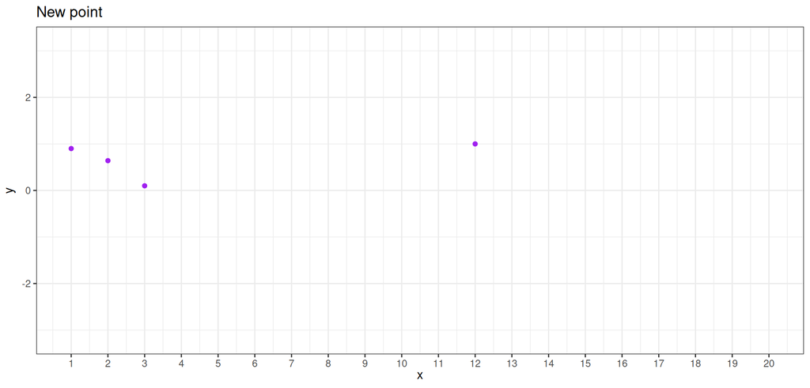

## Add a point further away

[figure not shown]

## Add a point further away

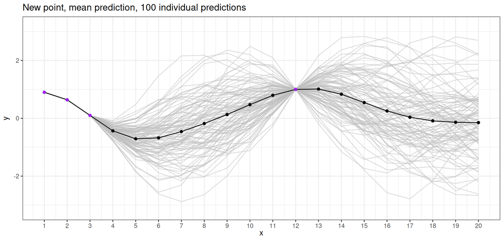

## Add a point further away

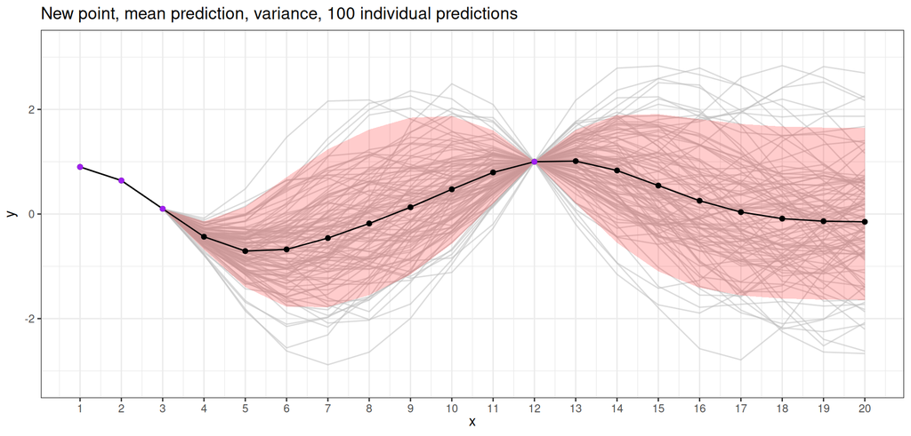

## Optimization using Gaussian Processes (Bayesian Optimization)

## Using Gaussian Processes for optimization

**Premise:** We have an unknown and *expensive-to-evaluate* objective function, \(f(x)\)

**Goal:** Return an value \(x_M\) which corresponds to an optimum \(f(x_M)\).

High evaluation cost requires selecting the location of new evaluations carefully.

## Bayesian Optimization simplified algorithm

In Bayesian optimization, a surrogate function (usually called an acquisition function) is used to select the next best evaluation location.

## Bayesian Optimization simplified algorithm

In Bayesian optimization, a surrogate function (usually called an acquisition function) is used to select the next best evaluation location.

**Algorithm:**

Repeat until some termination policy (e.g., convergence or exhaustion of resources):

1. Evaluate the objective function at a point.
2. Fit/update **Gaussian process** model with the data.
3. Optimize an acquisition function to select the next sampling point.

## Example of Bayesian Optimization in action

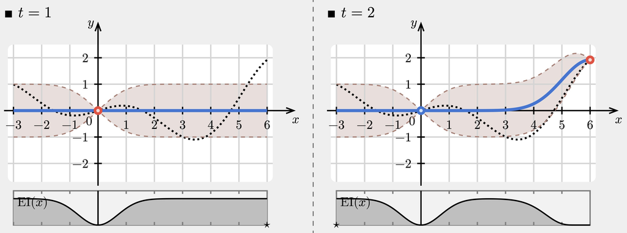

## Example of Bayesian Optimization in action

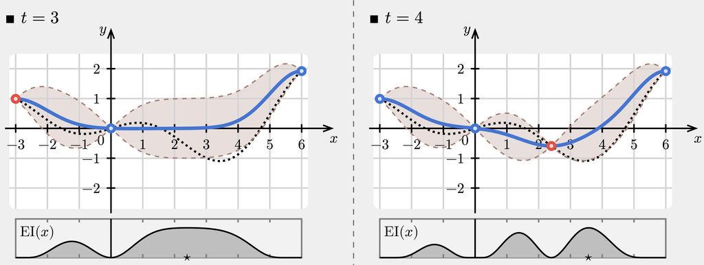

## Example of Bayesian Optimization in action

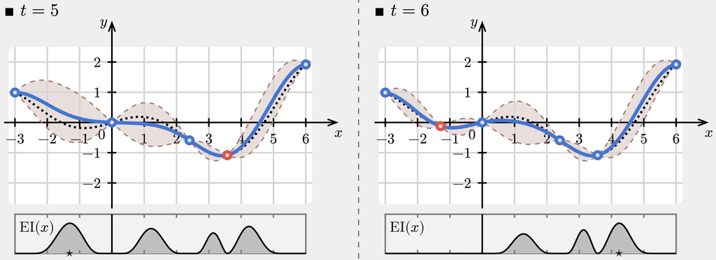

## Example of Bayesian Optimization in action

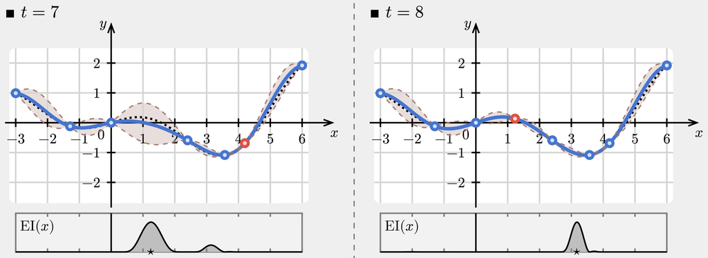

## Example of Bayesian Optimization in action

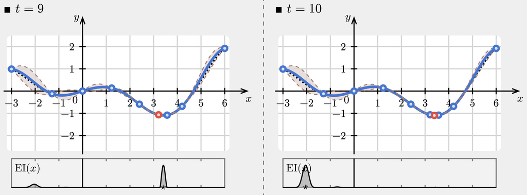

## Using Bayesian optimisation for boundary selection

## Basic methodology

Our goal is to optimise a black-box function, \(f\), which takes as inputs study design parameters, \(D\), and outputs study design characteristics, \(T\):

\[ f:D\rightarrow T \]

where

\[ D = \begin{bmatrix} \mathbf{u}\\ \boldsymbol{\ell}\\ n \end{bmatrix} \quad \text{and} \quad T=\begin{bmatrix} \alpha\\ \beta \end{bmatrix} \]

## Basic algorithm

Repeat until termination policy is reached:

## Basic algorithm

Repeat until termination policy is reached:

1. Generate a set of feasible trial designs, \(\mathbf{D} = \{D_1, \dots, D_j\}\).

## Basic algorithm

Repeat until termination policy is reached:

1. Generate a set of feasible trial designs, \(\mathbf{D} = \{D_1, \dots, D_j\}\).
2. Obtain the corresponding set of characteristics, \(\mathbf{T} = \{T_1, \dots, T_j\}\).

## Basic algorithm

Repeat until termination policy is reached:

1. Generate a set of feasible trial designs, \(\mathbf{D} = \{D_1, \dots, D_j\}\).
2. Obtain the corresponding set of characteristics, \(\mathbf{T} = \{T_1, \dots, T_j\}\).
3. Fit a Gaussian process regression model to estimate the function \(f:D\rightarrow T\)

## Basic algorithm

Repeat until termination policy is reached:

1. Generate a set of feasible trial designs, \(\mathbf{D} = \{D_1, \dots, D_j\}\).
2. Obtain the corresponding set of characteristics, \(\mathbf{T} = \{T_1, \dots, T_j\}\).
3. Fit a Gaussian process regression model to estimate the function \(f:D\rightarrow T\)
4. Perform a step of Bayesian optimisation to find the next trial design, \(D_i\).

## Basic algorithm

Repeat until termination policy is reached:

1. Generate a set of feasible trial designs, \(\mathbf{D} = \{D_1, \dots, D_j\}\).
2. Obtain the corresponding set of characteristics, \(\mathbf{T} = \{T_1, \dots, T_j\}\).
3. Fit a Gaussian process regression model to estimate the function \(f:D\rightarrow T\)
4. Perform a step of Bayesian optimisation to find the next trial design, \(D_i\).
5. Obtain the corresponding characteristics, \(T_i\).

## Basic algorithm

Repeat until termination policy is reached:

1. Generate a set of feasible trial designs, \(\mathbf{D} = \{D_1, \dots, D_j\}\).
2. Obtain the corresponding set of characteristics, \(\mathbf{T} = \{T_1, \dots, T_j\}\).
3. Fit a Gaussian process regression model to estimate the function \(f:D\rightarrow T\)
4. Perform a step of Bayesian optimisation to find the next trial design, \(D_i\).
5. Obtain the corresponding characteristics, \(T_i\).
6. Refit the GP model on the new data \(n\)-tuples, \(\{(\mathbf{D},\mathbf{T}),(D_i,T_i)\}\).

## The loss function \(\mathcal{L}\)

We have targets for the characteristics, e.g.,

- \(\alpha=0.05\),
- \(\beta=0.1\),
- and sample size.

## The loss function \(\mathcal{L}\)

We have targets for the characteristics, e.g.,

- \(\alpha=0.05\),
- \(\beta=0.1\),
- and sample size.

Our goal is to minimize the maximum expected sample size, which is calculated with the design elements \(D\) over a set of possible true treatment effects \(\boldsymbol{\delta}=\{\delta_1, \dots, \delta_n\}\).

\[ \mathbb{E}[N \, | \, \boldsymbol{\delta}]=\sum_{i=1}^k n_i P(\text{trial stops after analysis }i \, | \, \boldsymbol{\delta}) \]

## The loss function \(\mathcal{L}\)

We encode these “preferences” into a loss function:

\[ \mathcal{L}(T_i, \lambda) = (\alpha'-\alpha)^2\lambda+(\beta'-\beta)^2\lambda+\frac{\max(\mathbb{E}[N\,|\,\mathbf{\delta}])}{\lambda} \]

## The loss function \(\mathcal{L}\)

We encode these “preferences” into a loss function:

\[ \mathcal{L}(T_i, \lambda) = (\alpha'-\alpha)^2\lambda+(\beta'-\beta)^2\lambda+\frac{\max(\mathbb{E}[N\,|\,\mathbf{\delta}])}{\lambda} \]

where:

- \(T_i\) is a vector that contains the design’s calculated type I and type II error, and the per stage \(n\), that is, \(T_i=\{\alpha',\beta', n\}\).

## The loss function \(\mathcal{L}\)

We encode these “preferences” into a loss function:

\[ \mathcal{L}(T_i, \lambda) = (\alpha'-\alpha)^2\lambda+(\beta'-\beta)^2\lambda+\frac{\max(\mathbb{E}[N\,|\,\mathbf{\delta}])}{\lambda} \]

where:

- \(T_i\) is a vector that contains the design’s calculated type I and type II error, and the per stage \(n\), that is, \(T_i=\{\alpha',\beta', n\}\).
- \(\lambda\) is the single stage sample size for the design.

## The loss function \(\mathcal{L}\)

We encode these “preferences” into a loss function:

\[ \mathcal{L}(T_i, \lambda) = (\alpha'-\alpha)^2\lambda+(\beta'-\beta)^2\lambda+\frac{\max(\mathbb{E}[N\,|\,\mathbf{\delta}])}{\lambda} \]

where:

- \(T_i\) is a vector that contains the design’s calculated type I and type II error, and the per stage \(n\), that is, \(T_i=\{\alpha',\beta', n\}\).
- \(\lambda\) is the single stage sample size for the design.
- \(\alpha\) is the target type I error.

## The loss function \(\mathcal{L}\)

We encode these “preferences” into a loss function:

\[ \mathcal{L}(T_i, \lambda) = (\alpha'-\alpha)^2\lambda+(\beta'-\beta)^2\lambda+\frac{\max(\mathbb{E}[N\,|\,\mathbf{\delta}])}{\lambda} \]

where:

- \(T_i\) is a vector that contains the design’s calculated type I and type II error, and the per stage \(n\), that is, \(T_i=\{\alpha',\beta', n\}\).
- \(\lambda\) is the single stage sample size for the design.
- \(\alpha\) is the target type I error.
- \(\beta\) is the target type II error.

## The loss function \(\mathcal{L}\)

We encode these “preferences” into a loss function:

\[ \mathcal{L}(T_i, \lambda) = (\alpha'-\alpha)^2\lambda+(\beta'-\beta)^2\lambda+\frac{\max(\mathbb{E}[N\,|\,\mathbf{\delta}])}{\lambda} \]

where:

- \(T_i\) is a vector that contains the design’s calculated type I and type II error, and the per stage \(n\), that is, \(T_i=\{\alpha',\beta', n\}\).
- \(\lambda\) is the single stage sample size for the design.
- \(\alpha\) is the target type I error.
- \(\beta\) is the target type II error.
- \(\mathbb{E}[N \, | \, \boldsymbol{\delta}]\) defined previously.

## Results of several Bayes opt runs

## The following are set during Bayes opt runs

- 3 initial, valid bounds are given: Pocock, O’Brien-Fleming, and triangular

## The following are set during Bayes opt runs

- 3 initial, valid bounds are given: Pocock, O’Brien-Fleming, and triangular
- The loss function, \(\mathcal{L}\)

## The following are set during Bayes opt runs

- 3 initial, valid bounds are given: Pocock, O’Brien-Fleming, and triangular
- The loss function, \(\mathcal{L}\)
- GP regression kernel, e.g., squared exponential, Matérn

## The following are set during Bayes opt runs

- 3 initial, valid bounds are given: Pocock, O’Brien-Fleming, and triangular
- The loss function, \(\mathcal{L}\)
- GP regression kernel, e.g., squared exponential, Matérn
- Acquisition function, e.g., expected improvement

## The following are set during Bayes opt runs

- 3 initial, valid bounds are given: Pocock, O’Brien-Fleming, and triangular
- The loss function, \(\mathcal{L}\)
- GP regression kernel, e.g., squared exponential, Matérn
- Acquisition function, e.g., expected improvement
- Search space (see next slide)

## Seach space example

Taking a three-stage design as an example, the design parameters are

\[ D = \begin{bmatrix} u_1\\ u_2\\ u_3\\ \ell_1\\ \ell_2\\ n \end{bmatrix} \]

and our search space could be defined as

```
# design params  u_1  u_2  u_3  l_1  l_2  n
upper_bounds = [ 6,   6,   6,   6,   6,   60 ]
lower_bounds = [-6,  -6,  -6,  -6,  -6,    2 ]
```

## Reference loss function values

For reference, the loss function values \(\mathcal{L}(T_i, \lambda)\) for the given Pocock, O’Brien-Fleming, and triangular boundaries are:

| Boundary | Loss function value |
| --- | --- |
| Pocock | 0.372 |
| O’Brien-Fleming | 0.337 |
| Triangular | 0.271 |

## “Big box” search space

### Settings

- The loss function = \(\mathcal{L}(T_i, \lambda)\)
- GP regression kernel = Matérn 5/2
- Acquisition function = expected improvement

Search space:

```
# design params  u_1  u_2  u_3  l_1  l_2  n
upper_bounds = [ 6,   6,   6,   6,   6,   60 ]
lower_bounds = [-6,  -6,  -6,  -6,  -6,    2 ]
```

## “Big box” search space

### Results

- Of 1,000, 11 were valid study designs giving a “success” percentage of 1.1%

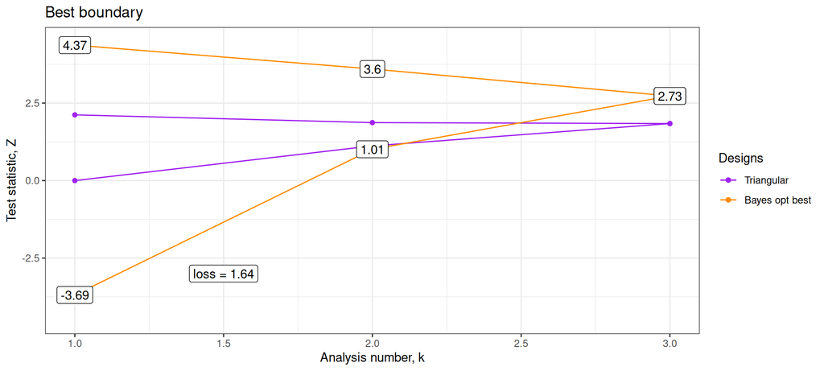

## “Big box” search space

### Results

- Selected sample size per stage: 40
- Maximum expected sample size: 98
- \(\alpha\) = 0.0032 (target 0.05)
- \(1-\beta\) = 0.96 (target 0.90)

## Enforce monotonicity with search space

### Settings

- The loss function = \(\mathcal{L}(T_i, \lambda)\)
- GP regression kernel = Matérn 5/2
- Acquisition function = expected improvement

Search space:

```
# design params  u_1  u_2  u_3  l_1  l_2  n
upper_bounds = [ 3,   3,   3,   0,   0,   30 ]
lower_bounds = [ 0,   0,   0,  -3,  -3,   10 ]
```

## Enforce monotonicity with search space

### Results

- Of 1,500, 121 were valid study designs giving a “success” percentage of 8.1%

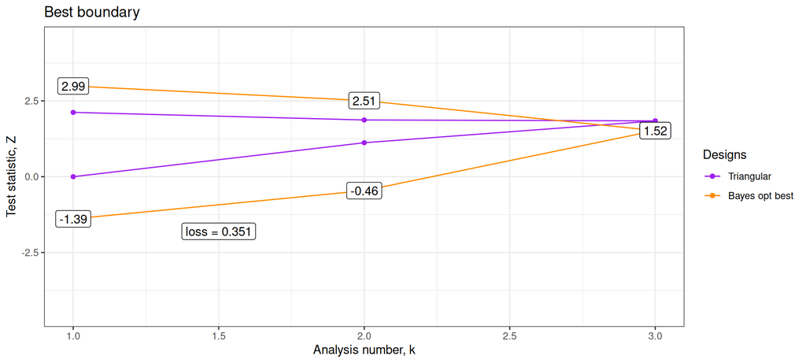

## Enforce monotonicity with search space

### Results

- Selected sample size per stage: 14
- Maximum expected sample size: 36
- \(\alpha\) = 0.065 (target 0.05)
- \(1-\beta\) = 0.87 (target 0.90)

## Penalize non-monotonicity + triangular search space

### Settings

Loss function: \[ \mathcal{L}(T_i, \lambda) = \begin{cases} (\alpha'-\alpha)^2\lambda+(\beta'-\beta)^2\lambda+\frac{\max(\mathbb{E}[N\,|\,\mathbf{\delta}])}{\lambda}&\text{if monotonic}\\ 25& \text{otherwise} \end{cases} \]

- GP regression kernel = Matérn 5/2
- Acquisition function = expected improvement

Search space:

```
# design params  u_1   u_2   u_3    l_1   l_2   n
upper_bounds = [ 2.38, 2.14, 2.10,  0.26, 1.39, 30 ]
lower_bounds = [ 1.86, 1.61, 1.57, -0.26, 0.86, 10 ]
```

## Penalize non-monotonicity + triangular search space

### Results

- Of 700, 327 were valid study designs giving a “success” percentage of 46.7%

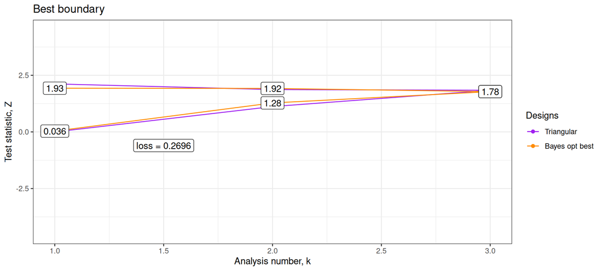

## Penalize non-monotonicity + triangular search space

### Results

- Selected sample size per stage: 22
- Maximum expected sample size: 35
- \(\alpha\) = 0.056 (target 0.05)
- \(1-\beta\) = 0.899 (target 0.90)

## Bayes opt with failure region

### Settings

- The loss function = \(\mathcal{L}(T_i, \lambda)\)
- Variational GP kernel = squared exponential, Bernoulli likelihood
- GP regression kernel = Matérn 5/2, Gaussian likelihood
- Acquisition function = product of expected improvement for GPR and probability of validity for the VGP

Search space:

```
# design params  u_1  u_2  u_3  l_1  l_2  n
upper_bounds = [ 3,   3,   3,   3,   3,   30 ]
lower_bounds = [-3,  -3,  -3,  -3,  -3,   10 ]
```

## Bayes opt with failure region

### Results

- Of 434, 17 were valid study designs giving a “success” percentage of 3.9%

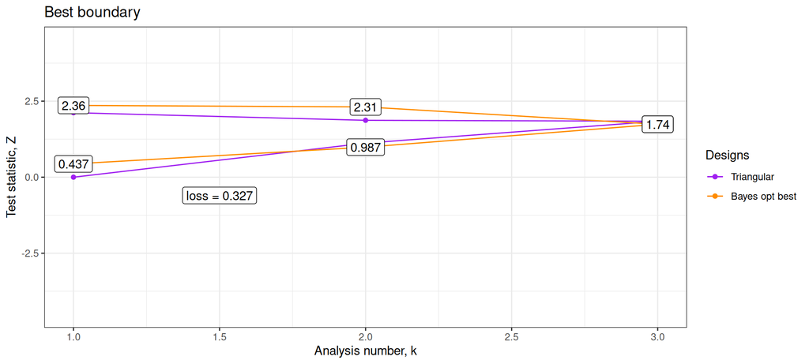

## Bayes opt with failure region

### Results

- Selected sample size per stage: 22
- Maximum expected sample size: 41
- \(\alpha\) = 0.039 (target 0.05)
- \(1-\beta\) = 0.89 (target 0.90)

## Future directions

- Monotonicity has been challenging to ensure while modeling the bounds directly.

## Future directions

- Monotonicity has been challenging to ensure while modeling the bounds directly.
- Next step will be to reparameterise the space in terms of the final boundary meeting point.

\[ c = u_K = \ell_K \]

## Future directions

- Monotonicity has been challenging to ensure while modeling the bounds directly.
- Next step will be to reparameterise the space in terms of the final boundary meeting point.

\[ c = u_K = \ell_K \]

We then model **non-negative boundary increments**, \(\Delta u_k\) and \(\Delta \ell_k\). For \(K\) stages,

\[ u_k = c + \sum^K_{j=k+1} \Delta u_j, \quad \ell_k = c - \sum^K_{j=k+1} \Delta \ell_j \]

## Future directions

- Monotonicity has been challenging to ensure while modeling the bounds directly.
- Next step will be to reparameterise the space in terms of the final boundary meeting point.

\[ c = u_K = \ell_K \]

We then model **non-negative boundary increments**, \(\Delta u_k\) and \(\Delta \ell_k\). For \(K\) stages,

\[ u_k = c + \sum^K_{j=k+1} \Delta u_j, \quad \ell_k = c - \sum^K_{j=k+1} \Delta \ell_j \]

Thus, the Bayes opt parameter vector then becomes \(D=\{n, c, \Delta u_2, \Delta \ell_2, \dots, \Delta u_K, \Delta \ell_K\}\).

## Acknowledgements

- Primary advisor: David Robertson
- Secondary advisor: Paul Kirk
- MRC BSU for its support and kindness!
- The Cambridge Trust

**Thank you!**

## Credit

Mathematics/derivations: Williams and Rasmussen (2006)

Inspiration for some of the visualizations: Turner (2016), Gramacy (2022a), and Gramacy (2022b)

Bayesian optimization visualization: Farina (2024)

Machine learning for trial design: Wason et al. (2012)

## References

Farina, Prof. Gabriele. 2024. “Lecture 16 - Bayesian Optimization.” Massachusetts Institute of Technology (MIT), April 25. https://www.mit.edu/~gfarina/2024/67220s24_L16_bayesian_optimization/L16.pdf.

Gramacy, Robert B. 2022a. “Surrogate Modeling and Bayesian Optimization.” Virginia Tech, September 21. https://www.youtube.com/watch?v=0Jj9ikDxqf4.

Gramacy, Robert B. 2022b. “Surrogate Modeling and Bayesian Optimization (Part 2).” Virginia Tech, September 21. https://www.youtube.com/watch?v=JKp32HVxIQs.

Turner, Richard. 2016. “Machine Learning Tutorial Series: Gaussian Processes.” Imperial College London, November 23. https://www.youtube.com/watch?v=92-98SYOdlY.

Wason, James MS, Adrian P Mander, and Simon G Thompson. 2012. “Optimal Multistage Designs for Randomised Clinical Trials with Continuous Outcomes.” *Statistics in Medicine* 31 (4): 301–12.

Williams, Christopher KI, and Carl Edward Rasmussen. 2006. *Gaussian Processes for Machine Learning*. Vol. 2. MIT press Cambridge, MA.